title: “Dlee71Fext” author: “Devante Lee1” date: “12/17/2020” output: html_document

install.packages(“arulesViz”, dependencies = T)

```r
library(arules)
library(TSP)
```

```r
library(arulesViz)
library(esquisse)
library(shiny)
library(factoextra)
library(dplyr)
library(naivebayes)
library(ggplot2)
library(e1071)
library(caret)
library(ISLR)
library(e1071)
library(pROC)
library(plotROC)
library(gmodels)
Bathsoap <- read.csv("C:/Users/Devante Lee/Downloads/BathSoap.csv")
```

```r
B5 <- kmeans(Bathsoap, centers = 5, nstart = 20)
```

```r
Bathsoapscaled <- scale(Bathsoap)
```

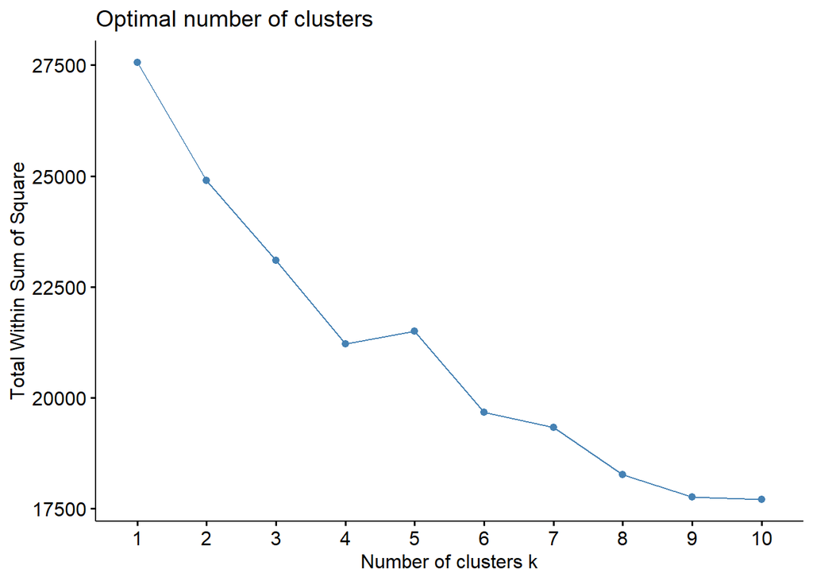

```r
  fviz_nbclust(Bathsoapscaled, kmeans, method = "wss")
```

```r
B5$centers
```

```
##   Member.id      SEC      FEH       MT      SEX      AGE      EDU       HS
## 1   1029243 3.555556 2.125000 8.652778 1.638889 3.138889 2.583333 4.500000
## 2   1153715 1.650224 1.645740 6.995516 1.650224 3.206278 4.721973 3.654709
## 3   1077503 3.044444 2.344444 8.855556 1.833333 3.555556 3.533333 4.655556
## 4   1057582 3.356322 2.482759 9.137931 1.827586 3.000000 3.471264 4.689655
## 5   1110498 2.421875 2.203125 8.843750 1.820312 3.171875 4.429688 4.289062
##      CHILD        CS Affluence.Index No..of.Brands Brand.Runs Total.Volume
## 1 3.361111 0.8472222        10.15278      3.208333   12.52778    13777.153
## 2 3.340807 0.8744395        20.83857      3.807175   17.10314     9439.493
## 3 3.111111 0.9888889        15.06667      3.455556   14.28889    14729.111
## 4 2.977011 0.9885057        12.98851      3.413793   14.51724    13090.632
## 5 3.234375 1.0000000        18.34375      3.859375   17.07812    12401.523
##   No..of..Trans    Value Trans...Brand.Runs Vol.Tran Avg..Price
## 1      27.93056 1196.734           3.800694 521.5353   8.790139
## 2      28.91928 1238.574           1.959641 355.7710  13.629417
```

[output cut: 33 more lines]

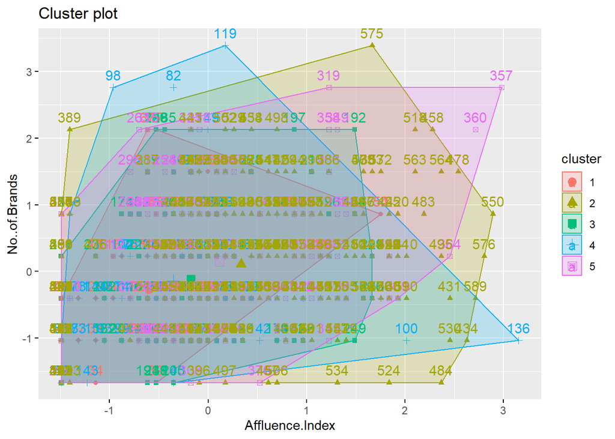

```r
fviz_cluster(B5, data = Bathsoap[,11:12])
```

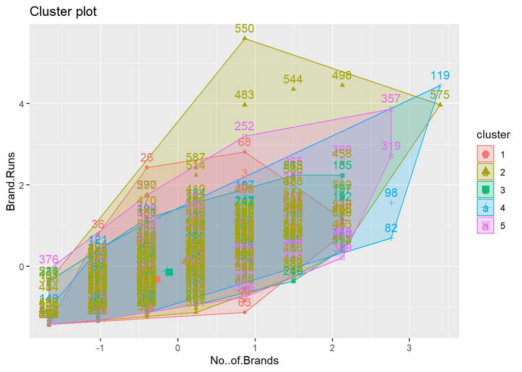

```r
fviz_cluster(B5, data = Bathsoap[,12:13])
```

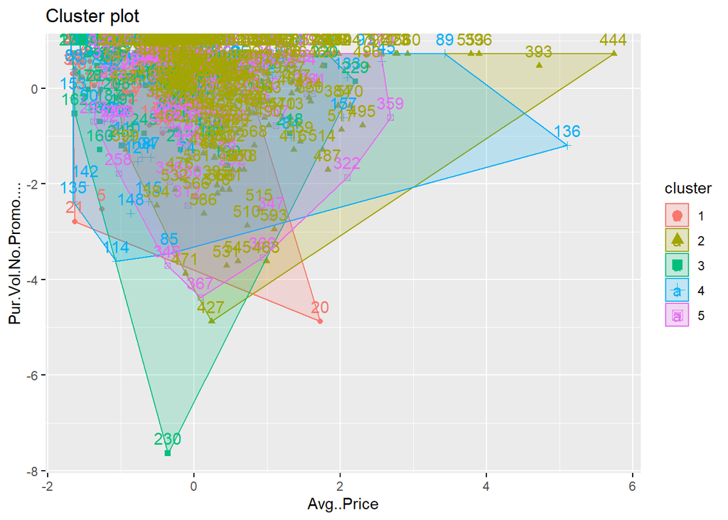

```r
fviz_cluster(B5, data = Bathsoap[,19:20])
```

1b. Cluster 3 is also the cluster that seems to purchase product most without any sort of discount attached to it. This is possibly the reason that the pricing of there items are much lower than other consumers. They will most likely be the consumer that IMRB customers should target if their customers are less willing to provide discounts, but are also attempting to move a large amount of products at a lower rate. Consumers in cluster 3 are my frst target as they are much more likely to purchase greater item qty than consumers in 1 & 2 of a brand for a longer period of time. When looking into these consumers it is clear that consumers in Cluster 3 & 5 are much more likely to purchase a greater amount of volume of one single brand (Br. Cd. 55), (5)0.225 and (3)0.359 are the largest qty of one single brand out of all items that will be purchased. This shows that loyalty in a brand is not the same between consumers. Br..Cd..55 clearly has the most loyalty of all consumers who are purchasing product Cluster 3 shows great loyalty to a specific brand when factoring in one of the most important factors when considering loyalty (Percentage of volume purchased of a brand). The only down fall of cluster 3 is the fact that they have the least # of Transactions of all clusters. So with high loyalty comes lower transactions. Meaning that there is a bit of give and take in this cluster. Cluster 5 is also a cluster to market at with their loyalty to a single brand and the grea volume that they purchase. With this cluster having a larger number of females it is extremely important ot hfactor in that they do a larger portion of the household shopping aong families. By using the brand share variables as is we have a much greater distance between customer clusters. This allows for those reviewing the data to better determine the actual averages of a cluster that have been reported by the consumer. This makes the data a bit easier to read a decipher in my humble opinoin. We would not want to use a single derived variable as that would calculate all of the variables based upon one variable which would skew our data and eventually skew our results as well.

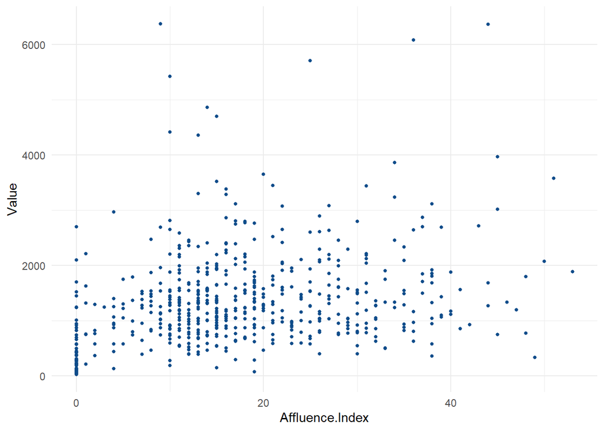

```r
ggplot(Bathsoap) +
 aes(x = Affluence.Index, y = Value) +
 geom_point(size = 1L, colour = "#0c4c8a") +
 theme_minimal()
```

2.(Demographics- Affluence Index) In attempting to find markets that are more likely to buy products it is pretty clear that poor to middle class consumers are more likely to be very Value intensive when looking at purchases. This is not a shock to anyone as poorer people have no choice but to look at value as an important factor of purchasing items. It is also important to see that there are many more consumers to market to by focusing on a Value intensive approach. This will lead to a much larger segmation of the market which will be able to purchase product. So a big factor on segmentation is to understanad that promotions toward lower priced product would be immensely beneficial to the overall growth of soap companies as these product will be purchased at such a high level. It should also be pointed out that the lower priced product don’t have a ton of coupon usage related to them in terms of when transactions are made.This shows that coupons would be less effective on this consumer as they understand what they are currently buying is already priced very fairly.

```r
Classmodel <- Bathsoap[c("SEC", "SEX", "HS", "Affluence.Index", "No..of.Brands", "Total.Volume", "No..of..Trans", "Avg..Price", "Br..Cd..55")]
```

```r
Classmodel$SEX [Classmodel$SEX == 0] <- "Male"
Classmodel$SEX [Classmodel$SEX == 1] <- "Male"
Classmodel$SEX [Classmodel$SEX == 2] <- "Female"
```

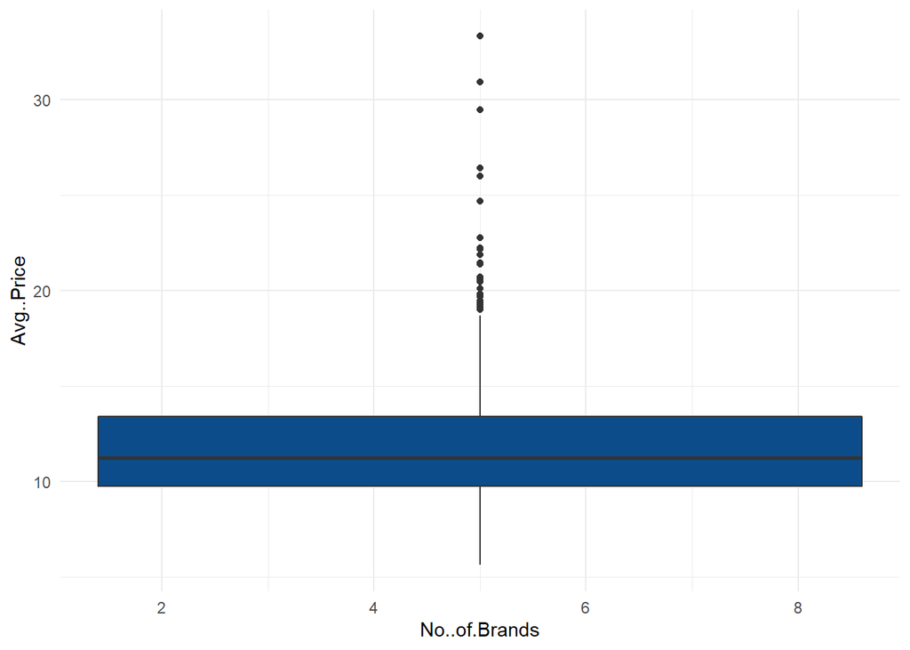

```r
ggplot(Classmodel) +
 aes(x = No..of.Brands, y = Avg..Price) +
 geom_boxplot(fill = "#0c4c8a") +
 theme_minimal()
```

```r
RBathsoap <- Bathsoap[1:300,]
RLBathsoap <- RBathsoap[,2:15]
Pracbathsop <- RBathsoap[,1:15]
```

```r
rules <-apriori(RLBathsoap)
```

```
## Apriori
##
## Parameter specification:
##  confidence minval smax arem  aval originalSupport maxtime support minlen
##         0.8    0.1    1 none FALSE            TRUE       5     0.1      1
##  maxlen target  ext
##      10  rules TRUE
##
## Algorithmic control:
##  filter tree heap memopt load sort verbose
##     0.1 TRUE TRUE  FALSE TRUE    2    TRUE
##
## Absolute minimum support count: 30
##
## set item appearances ...[0 item(s)] done [0.00s].
## set transactions ...[34 item(s), 300 transaction(s)] done [0.00s].
## sorting and recoding items ... [33 item(s)] done [0.00s].
## creating transaction tree ... done [0.00s].
## checking subsets of size 1 2 3 4 5 6 7 8 done [0.01s].
## writing ... [15496 rule(s)] done [0.00s].
## creating S4 object  ... done [0.01s].
```

```
## To reduce overplotting, jitter is added! Use jitter = 0 to prevent jitter.
```

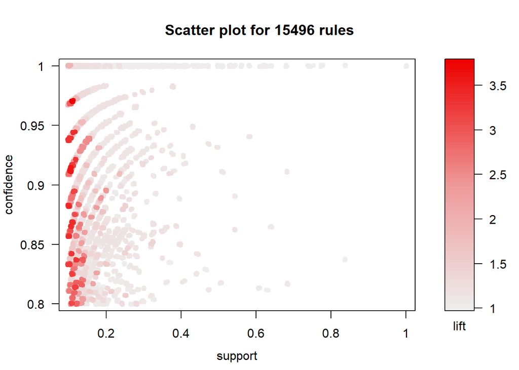

```r
plot(rules)
```

```r
inspect(rules[4:40])
```

```
##      lhs                         rhs                      support   confidence
## [1]  {CHILD=[1,2)}            => {SEX=[0,2]}              0.1000000 1.0000000
## [2]  {CHILD=[1,2)}            => {FEH=[0,3]}              0.1000000 1.0000000
## [3]  {CS=[0,1)}               => {Affluence.Index=[0,10)} 0.1366667 0.8367347
## [4]  {CS=[0,1)}               => {SEC=[3,4]}              0.1466667 0.8979592
## [5]  {CS=[0,1)}               => {SEX=[0,2]}              0.1633333 1.0000000
## [6]  {CS=[0,1)}               => {FEH=[0,3]}              0.1633333 1.0000000
## [7]  {HS=[4,5)}               => {MT=[10,17]}             0.1766667 0.8412698
## [8]  {HS=[4,5)}               => {CS=[1,2]}               0.1900000 0.9047619
## [9]  {HS=[4,5)}               => {SEX=[0,2]}              0.2100000 1.0000000
## [10] {HS=[4,5)}               => {FEH=[0,3]}              0.2100000 1.0000000
## [11] {SEC=[1,3)}              => {CS=[1,2]}               0.2066667 0.9253731
## [12] {SEC=[1,3)}              => {SEX=[0,2]}              0.2233333 1.0000000
## [13] {SEC=[1,3)}              => {FEH=[0,3]}              0.2233333 1.0000000
## [14] {MT=[0,10)}              => {SEX=[0,2]}              0.2500000 1.0000000
```

[output cut: 61 more lines]

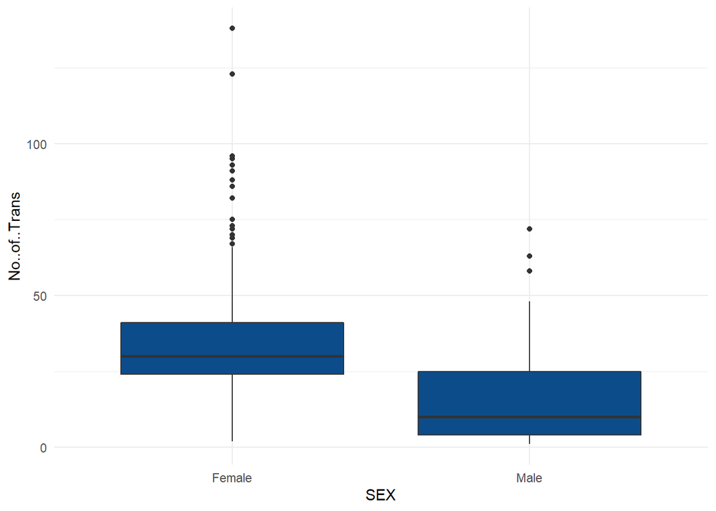

```r
ggplot(Classmodel) +
 aes(x = SEX, y = No..of..Trans) +
 geom_boxplot(fill = "#0c4c8a") +
 theme_minimal()
```

2.(Demographics- SEX) When looking at Gender IMRB customers must look to advertising at women (2). Women are more likely to make transactions over men. The chart above states that women are the primary household shoppers making them more likely to see the product that will be at stores. Advertising to women is a very solid approach when attempting to increase market share within most households.

```r
Newchart <- Bathsoap[c("SEC", "SEX", "HS", "Affluence.Index", "No..of.Brands", "Total.Volume", "No..of..Trans", "Br..Cd..55")]
```

```r
Newchart$SEX [Newchart$SEX == 0] <- "Male"
Newchart$SEX [Newchart$SEX == 1] <- "Male"
Newchart$SEX [Newchart$SEX == 2] <- "Female"

Newchart$Affluence.Index[Newchart$Affluence.Index == 0] <- "Poor"
Newchart$Affluence.Index[Newchart$Affluence.Index == 1] <- "Poor"
Newchart$Affluence.Index[Newchart$Affluence.Index == 2] <- "Poor"
Newchart$Affluence.Index[Newchart$Affluence.Index == 3] <- "Poor"
Newchart$Affluence.Index[Newchart$Affluence.Index == 4] <- "Poor"
Newchart$Affluence.Index[Newchart$Affluence.Index == 5] <- "Poor"
Newchart$Affluence.Index[Newchart$Affluence.Index == 6] <- "Poor"
Newchart$Affluence.Index[Newchart$Affluence.Index == 7] <- "Poor"
Newchart$Affluence.Index[Newchart$Affluence.Index == 8] <- "Poor"
Newchart$Affluence.Index[Newchart$Affluence.Index == 9] <- "Poor"
Newchart$Affluence.Index[Newchart$Affluence.Index == 10] <- "Poor"
Newchart$Affluence.Index[Newchart$Affluence.Index == 11] <- "Poor"
Newchart$Affluence.Index[Newchart$Affluence.Index == 12] <- "Poor"
Newchart$Affluence.Index[Newchart$Affluence.Index == 13] <- "Poor"
Newchart$Affluence.Index[Newchart$Affluence.Index == 14] <- "Poor"
Newchart$Affluence.Index[Newchart$Affluence.Index == 15] <- "Poor"

Newchart$Affluence.Index[Newchart$Affluence.Index == 16] <- "Middle"
Newchart$Affluence.Index[Newchart$Affluence.Index == 17] <- "Middle"
Newchart$Affluence.Index[Newchart$Affluence.Index == 18] <- "Middle"
Newchart$Affluence.Index[Newchart$Affluence.Index == 19] <- "Middle"
Newchart$Affluence.Index[Newchart$Affluence.Index == 20] <- "Middle"
Newchart$Affluence.Index[Newchart$Affluence.Index == 21] <- "Middle"
Newchart$Affluence.Index[Newchart$Affluence.Index == 22] <- "Middle"
Newchart$Affluence.Index[Newchart$Affluence.Index == 23] <- "Middle"
Newchart$Affluence.Index[Newchart$Affluence.Index == 24] <- "Middle"
Newchart$Affluence.Index[Newchart$Affluence.Index == 25] <- "Middle"
Newchart$Affluence.Index[Newchart$Affluence.Index == 26] <- "Middle"
Newchart$Affluence.Index[Newchart$Affluence.Index == 27] <- "Middle"
Newchart$Affluence.Index[Newchart$Affluence.Index == 28] <- "Middle"
Newchart$Affluence.Index[Newchart$Affluence.Index == 29] <- "Middle"
Newchart$Affluence.Index[Newchart$Affluence.Index == 30] <- "Middle"

Newchart$Affluence.Index[Newchart$Affluence.Index == 31] <- "High"
Newchart$Affluence.Index[Newchart$Affluence.Index == 32] <- "High"
Newchart$Affluence.Index[Newchart$Affluence.Index == 33] <- "High"
Newchart$Affluence.Index[Newchart$Affluence.Index == 34] <- "High"
Newchart$Affluence.Index[Newchart$Affluence.Index == 35] <- "High"
Newchart$Affluence.Index[Newchart$Affluence.Index == 36] <- "High"
Newchart$Affluence.Index[Newchart$Affluence.Index == 37] <- "High"
Newchart$Affluence.Index[Newchart$Affluence.Index == 38] <- "High"
Newchart$Affluence.Index[Newchart$Affluence.Index == 39] <- "High"
Newchart$Affluence.Index[Newchart$Affluence.Index == 40] <- "High"
Newchart$Affluence.Index[Newchart$Affluence.Index == 41] <- "High"
Newchart$Affluence.Index[Newchart$Affluence.Index == 42] <- "High"
Newchart$Affluence.Index[Newchart$Affluence.Index == 43] <- "High"
Newchart$Affluence.Index[Newchart$Affluence.Index == 43] <- "High"
Newchart$Affluence.Index[Newchart$Affluence.Index == 44] <- "High"
Newchart$Affluence.Index[Newchart$Affluence.Index == 45] <- "High"
Newchart$Affluence.Index[Newchart$Affluence.Index == 46] <- "High"
Newchart$Affluence.Index[Newchart$Affluence.Index == 47] <- "High"
Newchart$Affluence.Index[Newchart$Affluence.Index == 48] <- "High"
Newchart$Affluence.Index[Newchart$Affluence.Index == 49] <- "High"
Newchart$Affluence.Index[Newchart$Affluence.Index == 50] <- "High"
Newchart$Affluence.Index[Newchart$Affluence.Index == 51] <- "High"
Newchart$Affluence.Index[Newchart$Affluence.Index == 52] <- "High"
Newchart$Affluence.Index[Newchart$Affluence.Index == 53] <- "High"
Newchart$Affluence.Index[Newchart$Affluence.Index == 54] <- "High"
Newchart$Affluence.Index[Newchart$Affluence.Index == 55] <- "High"
Newchart$Affluence.Index[Newchart$Affluence.Index == 56] <- "High"
Newchart$Affluence.Index[Newchart$Affluence.Index == 57] <- "High"
Newchart$Affluence.Index[Newchart$Affluence.Index == 58] <- "High"
```

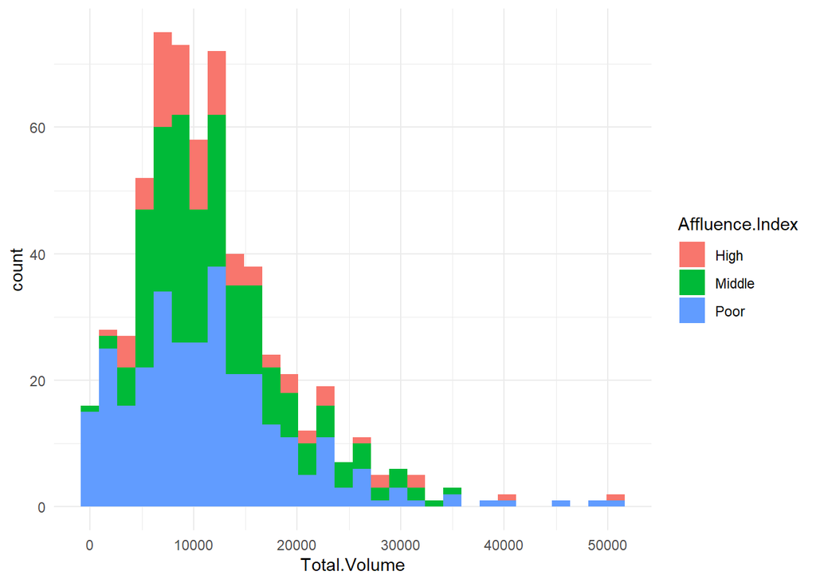

```r
ggplot(Newchart) +
 aes(x = Total.Volume, fill = Affluence.Index) +
 geom_histogram(bins = 30L) +
 scale_fill_hue() +
 theme_minimal()
```

2. (Purchase Behaivor) The Purchase behaivor shows clear correlation between Total Volume and poorer individuals. As we look at this bar chart it is clear that higher class consumers are not as likely to purchase a great volume of products the way that poorer consumers are willing to do. It is important to factor in that there are much fewer high class consumers which limits there ability to purchase a large qty of product. In saying that we also have to factor in that the Indian wealthy have around 54% of the entire wealth in India. So in saying the two former it is clear that the poorer & middle class consumers in India provide a much greater market to expand in and advertise to.

Naive Bayes Theory below

```r
Classmodel$No..of.Brands <- cut(Classmodel$No..of.Brands, 4)
```

```r
Classmodel$No..of.Brands <- factor(Classmodel$No..of.Brands)
Classmodel$Total.Volume <- factor(Classmodel$Total.Volume)
```

```r
set.seed(1234)
```

```r
Part <- createDataPartition(Classmodel$SEX, p = .7, list = F)

Classmodeltrain <- Classmodel[Part,]
Classmodeltest <- Classmodel[-Part,]
```

```r
Bay1 <- naive_bayes(SEX ~ . , data = Classmodeltrain)
Bay1
```

```
##
## ================================== Naive Bayes ==================================
##
##  Call:
## naive_bayes.formula(formula = SEX ~ ., data = Classmodeltrain)
##
## ---------------------------------------------------------------------------------
##
## Laplace smoothing: 0
##
## ---------------------------------------------------------------------------------
##
##  A priori probabilities:
##
##    Female      Male
```

[output cut: 508 more lines]

```r
Bayepred1 <- predict(Bay1, Classmodeltest, type = "class")
Bayepred1
```

```
##   [1] Male   Female Female Female Female Female Female Female Female Male
##  [11] Female Male   Male   Female Male   Male   Female Male   Female Female
##  [21] Female Female Female Female Female Female Female Male   Female Female
##  [31] Male   Female Male   Female Female Female Female Female Female Female
##  [41] Female Female Female Female Female Female Female Female Female Female
##  [51] Female Female Female Female Female Female Female Female Female Female
##  [61] Female Female Female Female Female Female Female Female Male   Female
##  [71] Female Female Male   Female Female Female Female Female Female Female
##  [81] Female Female Female Female Female Female Female Female Female Female
##  [91] Female Female Female Female Female Female Female Female Female Female
## [101] Male   Female Female Female Female Female Female Female Female Female
## [111] Female Female Female Male   Male   Female Female Male   Male   Male
## [121] Female Male   Female Male   Female Female Female Female Female Female
## [131] Female Female Male   Female Female Female Female Female Female Female
## [141] Male   Female Male   Female Female Female Female Female Female Female
## [151] Male   Female Female Female Female Female Male   Female Female Female
## [161] Female Female Female Female Female Female Male   Female Male   Female
## [171] Male   Female Female Female Female Female Female Female Female
## Levels: Female Male
```

3. By using this naive bayes & apriori algolrithm it is clear that our targeted consumers have the below characteristics as a group:
1. Women
2. Ages 40 and up.
3. Middle to Poor Socioeconomic status
4. Large households

```r
table(x = Classmodel$SEX , y = Classmodel$Total.Volume)
```

[output not shown]

[output cut: 97 more lines]

[output not shown]